# Exploration filtering and model criteria for differential gene analysis

adowneywall

8/13/2019

### Purpose

The two primary purposes of this script are to (1) explore different strategies for pruning or filtering a gene (or transcript) count matrix to include only informative features (i.e. remove features that have low or sparse counts) and (2) take a closer look at the use of different model structures and contrasts for the purpose of differential expression analysis in the package `limma`. The latter purpose will serve to help clarify the best way to write the model in order to address the specific hypotheses we are interested in.

**Libraries**

```r
## Packages
library(matrixStats,quietly = TRUE)
library(edgeR,quietly = TRUE)
library(limma,quietly = TRUE)
library(fdrtool,quietly = TRUE)
library(kableExtra,quietly = TRUE)
library(DESeq2,quietly = TRUE)
library(dplyr,quietly = TRUE)
library(variancePartition,quietly = TRUE)
library(FSA,quietly = TRUE) # to use w arguement in hist()
```

**Data**

*Gene and Transcript Expression Matrices*

```r
#### RSEM counts ####
# Gene matrix
RSEM <-  readRDS("/home/downeyam/Github/2017OAExp_Oysters/input_files/RNA/STAR_mapping/RSEM_output/RSEM_gene_Summary.Rdata")
# Separate out RSEM counts and rename rows with LOC ID
rsem_c <- RSEM$Count # Stick with raw gene counts  (not TPM or some other normalizaed count)
rm(RSEM)

# Isoform (transcript) matrix
RSEM_t <-  readRDS("/home/downeyam/Github/2017OAExp_Oysters/input_files/RNA/STAR_mapping/RSEM_output/RSEM_isoform_Summary.Rdata")
rsem_t_c <- RSEM_t$Count
rm(RSEM_t)

dim(rsem_c)
```

```
## [1] 38929    24
```

```r
# 38929 genes
dim(rsem_t_c)
```

```
## [1] 67290    24
```

```r
# 67290 transcripts
```

*Transcript annotation file*

```r
#### Transcript File ####
# Transcript file
tran <- readRDS("/home/downeyam/Github/2017OAExp_Oysters/input_files/RNA/references/STAR_gnomon_tximportGeneFile.RData")
# Gene File
gene <- tran[!duplicated(tran$GENEID),]

kable(head(gene)) %>%
    kable_styling() %>%
    scroll_box(width = "90%", height = "150px")
```

|  | GENEID | TXNAME | gene_id | chr | start | stop | predict |
| --- | --- | --- | --- | --- | --- | --- | --- |
| 1 | LOC111099029 | rna1054_gene612 | gene612 | NC_035780.1 | 10259069 | 10283250 | transient receptor potential cation channel subfamily M member 6-like |
| 2 | LOC111099030 | rna1776_gene1029 | gene1029 | NC_035780.1 | 17038826 | 17040196 | uncharacterized LOC111099030 |
| 3 | LOC111099031 | rna29038_gene16843 | gene16843 | NC_035784.1 | 2415607 | 2420144 | uncharacterized LOC111099031, transcript variant X1 |
| 6 | LOC111099032 | rna34148_gene19798 | gene19798 | NC_035784.1 | 44161978 | 44164445 | 5-hydroxytryptamine receptor-like |
| 7 | LOC111099033 | rna1584_gene901 | gene901 | NC_035780.1 | 14629934 | 14638596 | solute carrier family 23 member 2-like |
| 8 | LOC111099034 | rna31874_gene18496 | gene18496 | NC_035784.1 | 27144536 | 27148489 | uncharacterized LOC111099034 |

*Sample meta data*

```r
#### Meta Data ####
meta <- readRDS("/home/downeyam/Github/2017OAExp_Oysters/input_files/meta/metadata_20190811.RData")
meta$sampl_nameSimple <- substr(meta$sample_name,start = 4,stop=9)
#Create new factor levels (one for each level combination)
meta$SFVrn <- as.factor(paste0("D",meta$SFV))
meta$Sample_Index <- as.factor(meta$sample_index)
meta$TankID <- as.factor(meta$tankID)
```

*Data Clean-up*

Here I reordered both the count matrices (gene and transcript) and annotation objects for when I combine them in the DGEList object downstream.

```r
#### Data Manipulation ####
# Order genes from annotation list to match the order in the count matrix
gene_order <- gene[order(gene$gene_id),]
identical(rownames(rsem_c),gene_order$gene_id) # TRUE confirms the order matches
```

```
## [1] TRUE
```

```r
# Relabel the rows of the count matrix with LOC ID
rownames(rsem_c) <- gene_order$GENEID

# Order transcripts from annotation list to match the order from the count matrix
rsem_t_order <- rsem_t_c[order(rownames(rsem_t_c)),]
tran_order <- tran[order(tran$TXNAME),]
identical(rownames(rsem_t_order),tran_order$TXNAME)
```

```
## [1] TRUE
```

```r
# I am not renaming the rows here since the TXNAME will be unique, while the gene LOC will be redundant for isoforms from the same gene. However, the reordering here is still needed when the annotations get added to the DGEList later.

# Reorder by LOCID
geneC_full <- rsem_c
tranC_full <- rsem_t_order

rm(rsem_c)
rm(rsem_t_order)

# Summary table
name <- c("Genes","Isoforms")
featureC <- c(nrow(geneC_full),nrow(tranC_full))
meanCount <- c(mean(colSums(geneC_full)),mean(colSums(tranC_full)))
maxCount <- c(max(colSums(geneC_full)),max(colSums(tranC_full)))
minCount <- c(min(colSums(geneC_full)),min(colSums(tranC_full)))

summary_df <- data.frame(Feature=name,Num_Features=featureC,
                         mean_Sum=meanCount,min_Count=minCount,max_Count=maxCount)
kable(summary_df)%>%
    kable_styling() %>%
    scroll_box(width = "90%", height = "125px")
```

| Feature | Num_Features | mean_Sum | min_Count | max_Count |
| --- | --- | --- | --- | --- |
| Genes | 38929 | 13456348 | 11592273 | 16427649 |
| Isoforms | 67290 | 13456348 | 11592273 | 16427649 |

### Plan

Using both gene and transcript count matrices generated using a `STAR` to `RSEM` workflow I wanted to examine differential expression using a standard linear fit modelling approach following a general `limma-voom` pipeline for the analysis. Within the pipeline I explore the impact of **two different filtering approaches** and **two different (but equivalent) linear model formula options**. The later was more of an exploration into the way in which `limma-voom` codes the model formula and how to approriately create contrasts.

### Differential expression workflow

- Round Counts, filter, and create DGEList with `edgeR`
  - **Approach 1**: Filter out features with fewer than 1 count per million (cpm) in less than 6 individuals.
  - **Approach 2**: Filter out features with fewer than 1 count per million in at least one time*treatment level (n=5)
- Normalize Counts with `edgeR`
  - Using the **TMMswp** approach for normalization
- Create design matrix
  - **Option 1**: Design matrix that handles two explanatory factors (time and treatment) as a single categorical variable with 4 levels, making it easier to setup planned contrasts.
  - **Option 2**: Design matrix that keep time and treat as separate 2 level factors and used the traditional `time*treatment` formula notation.
- Create contrasts
  - Contrasts only created using the design matrix from *Option 1*
- Transform and determine observational weights with `limma-voom`
  - Used the `voomWithQualityWeights()` approach
- Account for random tank effect
  - Used to account for a confounding tank effect I used the `duplicateCorrelation()` function from `limma`
- Fit linear model and perform empirical Bayes procedure
  - Used `lmFit()` with the `duplicateCorrelation` arguement to fit the linear model
  - Used `eBayes()` to perform the empirical Bayes procedure
- Create a list of Top Candidates
- Data Visualization and volcano plots

### Round counts, filter, and create DGEList with `edgeR`

- Counts are rounded prior to filtering and creating the DGEList object for downstream analysis
- Filter out uninformative features (ones with low coverage)
  - **Approach 1**: Here I used a more standard approach (threshold based on my conversation with Adam), which will filter out features that do not contain at least 1 count per million in at least six samples. **Rationale**: There are 4 distinct levels in this experimente, each with 6 samples. So if a feature is only expressed in one of the four levels than we might have a scenario where only 6 samples display some level of expression. **Downside**: This doesn’t distinguish which experimental level each of the 6 samples originated from, so it’s possible that the samples are not concentrated in any particular `treatment*time` combination. As a result, you could have a scenario were only 2 samples from each `treatment*time` level exhibit expression at a particular feature. A feature with this pattern will likely not be significant, but may be problematic if expression is high enough in the few individuals that exhibit expression.
  - **Approach 2**: This extends approach one, requiring a minimum number of samples that exhibit a cpm of at least 1 in 5 individual (rather than 6). However, this time it looks within each `treat*time` level to ensure that there is expression for at least 5 of the 6 individuals. **Rationale**: This approach helps with the potential downside of approach 1, by ensuring that feature expression if not ubiqutious across all samples is at least concentrated in one experiment level (what we might expect if one experimental level was significantly different than all other levels). **Downside**: This will be more conservative than approach 1 (although I would argue will more likely remove uninformative features), and may not handle individual variation as well as approach 1 (i.e. if two individuals lack expression within a particular treatment due individual level variation this will lead to the exclusion that feature). The current threshold attempts to account for this by relaxing the number of individuals that exhibit expression within a level (a minimum of 5 of the 6 individuals need to have at least 1 cpm). However, this could be relaxed further if we are filtering our too many features.

```r
# Round to whole counts
geneC_all <- round(geneC_full)
tranC_all <- round(tranC_full)

### Approach 1
## Filtering criteria based on count representation in at least 6 samples (1 treatment)
# Gene level
keep_gene_a1 <- rowSums(cpm(geneC_all)>1) >= (6) # min six
par(mfrow=c(2,1))
hist(rowSums(cpm(geneC_all)>1),xlab="Num. of samples with at least 1 cpm",main="Filtering Thresholds (genes)")
abline(v=6,col="red")
paste0(sum(keep_gene_a1)," of ",summary_df$Num_Features[1]," genes kept after filtering (",
       round(sum(keep_gene_a1)/summary_df$Num_Features[1]*100,2),"% remaining).")
```

```
## [1] "23743 of 38929 genes kept after filtering (60.99% remaining)."
```

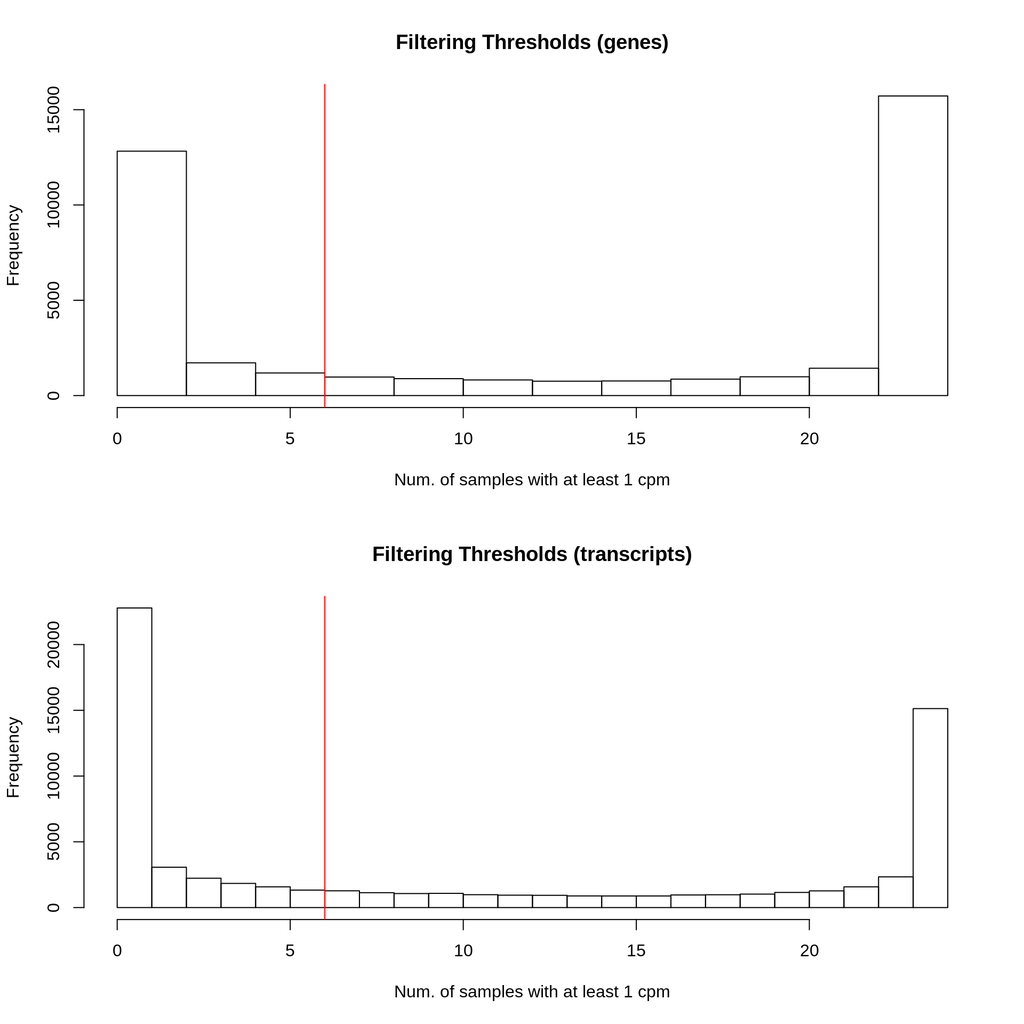

```r
# Transcript level
keep_tran <- rowSums(cpm(tranC_all)>1) >= (6)
hist(rowSums(cpm(tranC_all)>1),xlab="Num. of samples with at least 1 cpm",main="Filtering Thresholds (transcripts)")
abline(v=6,col="red")
```

```r
paste0(sum(keep_tran)," of ",summary_df$Num_Features[2]," transcripts kept after filtering (",
       round(sum(keep_tran)/summary_df$Num_Features[2]*100,2),"% remaining).")
```

```
## [1] "35796 of 67290 transcripts kept after filtering (53.2% remaining)."
```

```r
### Approach 2 (for the moment just look at approach 2 in the context of genes)
## Breaking down expression coverage by treatment*time combination
#Day 9 Trt 2800
keep_D9.2800 <- rowSums(cpm(geneC_all[,meta$SFVrn=="D09.2800"])>=1) >= 5
sum(keep_D9.2800)
```

```
## [1] 18649
```

```r
#Day 9 Trt 400
keep_D9.400 <- rowSums(cpm(geneC_all[,meta$SFVrn=="D09.400"])>=1) >= 5
sum(keep_D9.400)
```

```
## [1] 18599
```

```r
#Day 80 Trt 2800
keep_D80.2800 <- rowSums(cpm(geneC_all[,meta$SFVrn=="D80.2800"])>=1) >= 5
sum(keep_D80.2800)
```

```
## [1] 18445
```

```r
#Day 80 Trt 400
keep_D80.400 <- rowSums(cpm(geneC_all[,meta$SFVrn=="D80.400"])>=1) >= 5
sum(keep_D80.400)
```

```
## [1] 18419
```

```r
hist(rowSums(cbind(keep_D9.2800,keep_D9.400,
                                 keep_D80.2800,keep_D80.400)),main="Distribution of features shared among experimental levels for at least 5 individuals",xlab="Number of experimental levels meeting filtering criteria")

keep_gene_a2 <- rowSums(cbind(keep_D9.2800,keep_D9.400,
                                 keep_D80.2800,keep_D80.400)) >= 1
paste0(sum(keep_gene_a2)," of ",summary_df$Num_Features[1]," genes kept after filtering (",
       round(sum(keep_gene_a2)/summary_df$Num_Features[1]*100,2),"% remaining).")
```

```
## [1] "20387 of 38929 genes kept after filtering (52.37% remaining)."
```

```r
# Filter genes - approach 1
geneC_a1 <- geneC_all[keep_gene_a1, ]
gene_final_a1 <- gene_order[keep_gene_a1,]
# Filter genes - approach 2
geneC_a2 <- geneC_all[keep_gene_a2, ]
gene_final_a2 <- gene_order[keep_gene_a2,]
#Filter transcripts - approach 1
tranC_a1 <- tranC_all[keep_tran, ]
tran_final <- tran_order[keep_tran, ]

# Create DGEList
dge_gene_a1 <- DGEList(geneC_a1,genes = gene_final_a1) # counts - rsem
dge_gene_a2 <- DGEList(geneC_a2,genes = gene_final_a2) # counts - rsem
dge_tran_a1 <- DGEList(tranC_a1,genes = tran_final) # counts - rsem

#saveRDS(dge_gene_a2,"/home/downeyam/Github/2017OAExp_Oysters/results/Transcriptomic/DGEListObj_filterApproach2.RData")
```

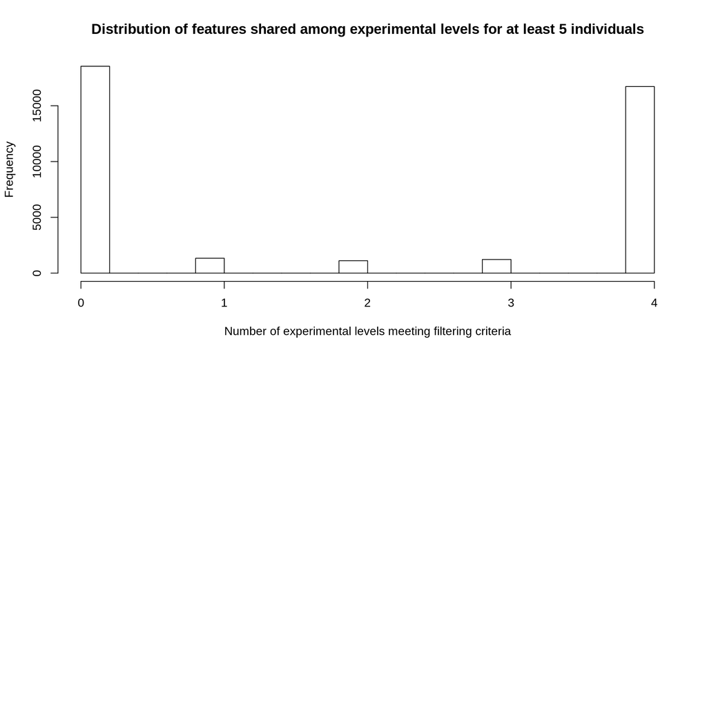

### Normalization with edgeR

**Note about TMMwsp method**: Stands for “TMM with singleton pairing”. This is a variant of TMM that is intended to perform better for data with a high proportion of zeros. In the TMM method, genes that have zero count in either library are ignored when comparing pairs of libraries. In the TMMwsp method, the positive counts from such genes are reused to increase the number of features by which the libraries are compared. The singleton positive counts are paired up between the libraries in decreasing order of size and then a slightly modified TMM method is applied to the re-ordered libraries.

**Other forms of normalization**: I tried the more standard `TMM` method as well as no normalization approach `method="none"`, but found little difference in the final output. I ended up sticking with the method that best seemed to handle the potential for zero gene expression.

```r
# Calculate normalization factors for scaling raw lib. size
dge_gene_a1_norm <- calcNormFactors(dge_gene_a1,method = "TMMwsp") # gene - approach 1
dge_gene_a2_norm <- calcNormFactors(dge_gene_a2,method = "TMMwsp") # gene - approach 2
dge_tran_a1_norm <- calcNormFactors(dge_tran_a1,method="TMMwsp")   # transcript - approach 1

test <- voom(dge_gene_a1_norm)
head(test$E)
```

```
##                   17005     17007      17013      17019       17069
## LOC111126949  2.7484060  3.509473  1.8820396  2.1303949  1.90701714
## LOC111128971  5.6750079  5.222265  5.1753716  5.2645026  5.02948079
## LOC111119734 -0.7263736 -1.160774  1.0713099 -0.6571967 -0.38716597
## LOC111123218 -1.3544048  2.338458 -1.1589877  4.4760067  0.07849761
## LOC111123219 -2.4919083  1.768142 -0.6114999  1.2903359  0.42996998
## LOC111123220  4.0779473  4.365198  4.5047073  3.9976098  4.20635855
##                   17070       17072      17079      17090      17094
## LOC111126949  1.8718178  2.61679668  1.8444647  1.8422865  2.2638407
## LOC111128971  4.8700659  5.41006267  4.5872673  5.0790800  5.4662785
## LOC111119734 -1.1142430  0.06098052  0.2595022 -0.3855195 -0.9060844
## LOC111123218  0.9132378 -0.33494815 -1.4905195 -1.8260921 -0.5190612
## LOC111123219  0.1395136 -1.12344405  0.9326919 -0.1098850  0.3476722
## LOC111123220  4.2701257  4.59454387  3.9049172  4.1247762  4.3093553
##                   17099      17108      17122      17130      17142
## LOC111126949  3.2329136  2.6838453  1.9744754  2.0611280  2.1434564
## LOC111128971  5.2037160  5.4828769  5.1522948  5.2027640  5.1757252
## LOC111119734 -0.1771058  0.3226578  0.4926064 -0.2330551  1.4515787
## LOC111123218  3.7297848 -0.4478604  0.5888217 -0.3774450 -0.3228616
## LOC111123219 -4.9319933  1.1371021 -4.3653746 -1.8180176 -4.5707892
## LOC111123220  4.1843507  4.1335618  4.8849238  4.0923039  4.2333419
##                    17145       17162      17174       17176     17178
## LOC111126949  3.13674090  2.65073080  1.9164689  1.64060027  1.528312
## LOC111128971  5.30861155  5.17098761  5.1269217  4.98065498  5.511707
## LOC111119734  0.04635467  0.09085928  1.9649674  0.15185308  1.444654
## LOC111123218 -0.72416349 -1.06668200 -0.3100396  0.05563777 -1.451511
## LOC111123219  2.19960093 -1.95976679 -4.9538958 -4.80234323 -1.814081
## LOC111123220  4.01174091  4.56603363  4.8486206  4.29305380  4.182695
##                    17181      17203      17211      17213
## LOC111126949  1.99860763  4.0040655  2.9541106  1.5828503
## LOC111128971  5.70112018  5.5016408  5.0633220  5.4079575
## LOC111119734  1.40688776 -0.5414669 -0.1367428  0.7115836
## LOC111123218 -0.09900317 -1.1694981 -0.2570370 -0.7390778
## LOC111123219 -4.74285936 -1.1694981 -0.6931362  1.7290710
## LOC111123220  4.32053572  4.3339663  4.3305367  4.2518771
```

### Create design matrix

The linear model approach by `limma-voom` requires a design matrix that informs the model fitting function (`lmFit`) the assignment of each individual amongst the experimental levels (i.e. which treatment or time the individual belongs too). According to the `limma-voom` manual you can code this matrix in different ways yet still arrive at equivalent answers (similar to most other linear modeling functions). I decide on two options that represent equivalent ways of representing the different levels of the experiment, but have different default contrasts. *Option 1* handles each treatment and time combination as seperate levels (single factor with 4 total experimental levels), while *Option 2* maintains them as separate 2 level factors. Page 45 of the manual.

**Design matrix specifics**

- Option 1: **design** - Combining time (2 level factor) and treatment (2 level factor) into a single 4 level explanatory factor for the purpose of making the specific contrasts (planned comparisons easier to code). This was a stragey implemented in the limma manual.
  - Single explanatory factory - **SFVrn** - “D09.2800” “D09.400” “D80.2800” “D80.400”
- Option 2: **design_alt** - Treatment and time handled as separate factors, using "*" to indicate the inclusion of an interaction.
  - Time - “09” “80”
  - Treatment - “400” “2800”

```r
## Option 1
design <- model.matrix(~0+SFVrn,data=meta) # 0+ is needed here otherwise the first level defaults to 1.
#Rename columns
colnames(design) <- levels(meta$SFVrn)
## Option 2
design_alt <- model.matrix(~Treatment*Time,data=meta)
```

### Contrasts using `design` matrix

Using the **Option 1** matrix it is easier to perform some of the focal contrasts that I was particularly interested in. Specifically, I was interested in three primary contrasts + the interaction:  
1) CvE_D9 : Difference between ambient and OA at day 9  
2) CvE_D80 : Difference between ambient and OA at day 80  
3) C_D9D80 : Difference at ambient between day 9 and day 80  
4) Diff : Interaction between treatment and time

- In this case the Diff should be equivalent to the interaction (`Treatment:Time`) from *Option 2*

```r
#Create specific contrasts for option 1
contr_mat <- makeContrasts(
  CvE_D9 = D09.2800-D09.400,
  CvE_D80 = D80.2800-D80.400,
  C_D9vD80 = D09.400-D80.400,
  Diff = (D09.2800-D09.400)- (D80.2800-D80.400),
  levels=design
)
```

### Transform and create observational level weights

- Use `voomWithQualityWeights` from `limma` package
  - Part of limma package. Will transform count data to log2-count per million (logCPM), and estimate the mean-variance relationship. This will then be leveraged to compute the appropriate observation-level weights.
  - " When a multi-dimensional scaling plot from a designed RNA-seq experiment indicates the presenceof outlier samples, it is possible to combine the observation-level weighting strategy used in voomwith sample-specific quality weights (as described in the section above on Array Quality Weights) todown-weight outlier samples. This capability is implemented in thevoomWithQualityWeightsfunction. "

**Note**: I am performing the transformation on both filtered gene sets (a1 vs a2) and passing along both design matrices (o1 vs. o2). At a result there will be 4 different gene feature objects and 1 transcript feature (a1 + o1) object.

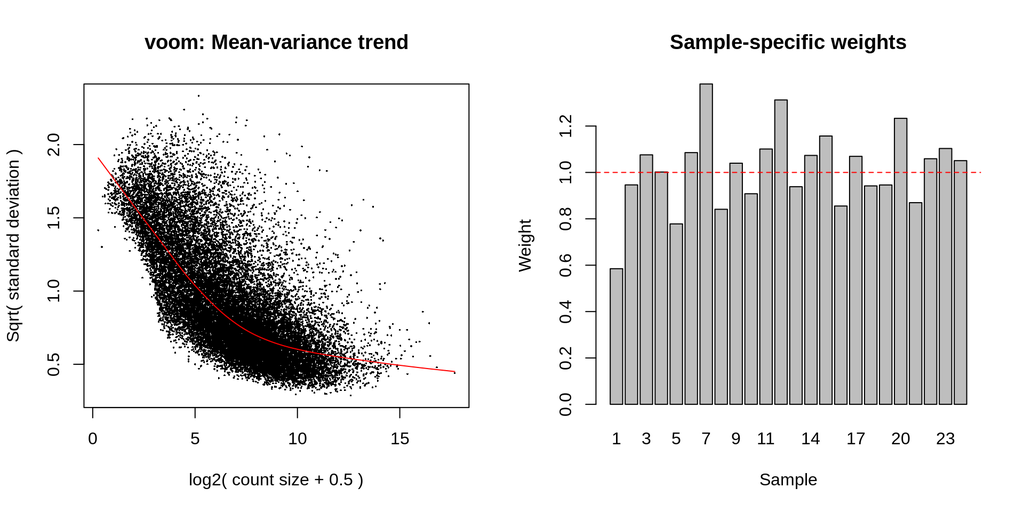

```r
## Gene Features - Filtering approach 1 - Model option 1
dge_gene_a1_o1_voom <- voomWithQualityWeights(dge_gene_a1_norm,design,plot = TRUE)
```

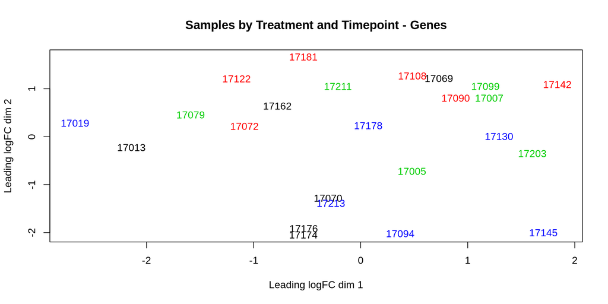

```r
# Simple MDS with samples colored by their treatment x time levels
plotMDS(dge_gene_a1_o1_voom,col=as.numeric(interaction(meta$treatment,meta$timepoint)),main="Samples by Treatment and Timepoint - Genes")
```

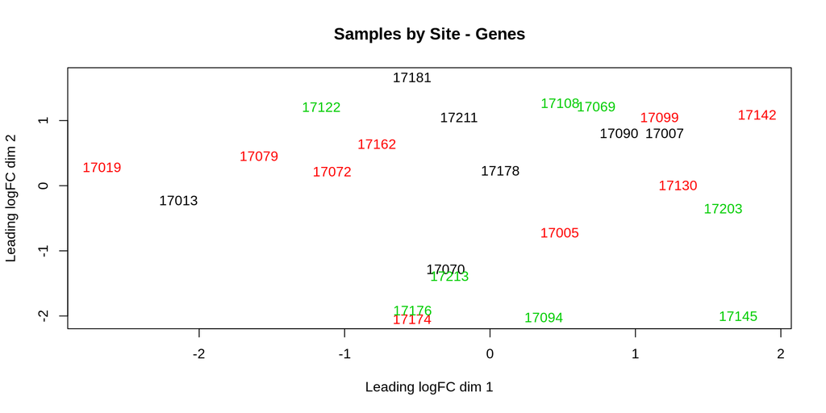

```r
# Simple MDS with samples colored by their site
plotMDS(dge_gene_a1_o1_voom,col=as.numeric(meta$Pop),main="Samples by Site - Genes")
```

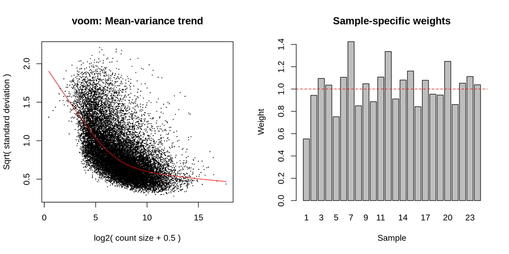

```r
## Gene Features - Filtering approach 2 - Model option 1
dge_gene_a2_o1_voom <- voomWithQualityWeights(dge_gene_a2_norm,design,plot = TRUE)
```

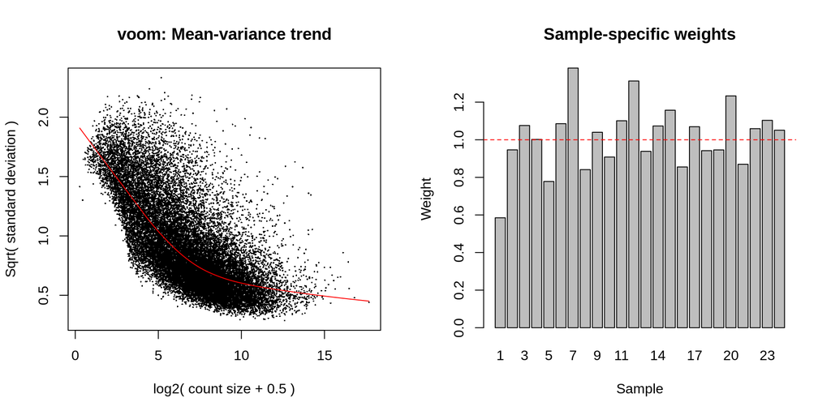

```r
## Gene Features - Filtering approach 1 - Model option 2
dge_gene_a1_o2_voom <- voomWithQualityWeights(dge_gene_a1_norm,design_alt,plot = TRUE)
```

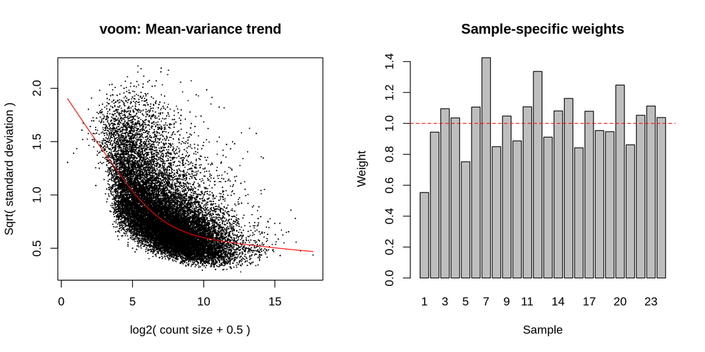

```r
## Gene Features - Filtering approach 1 - Model option 2
dge_gene_a2_o2_voom <- voomWithQualityWeights(dge_gene_a2_norm,design_alt,plot = TRUE)
```

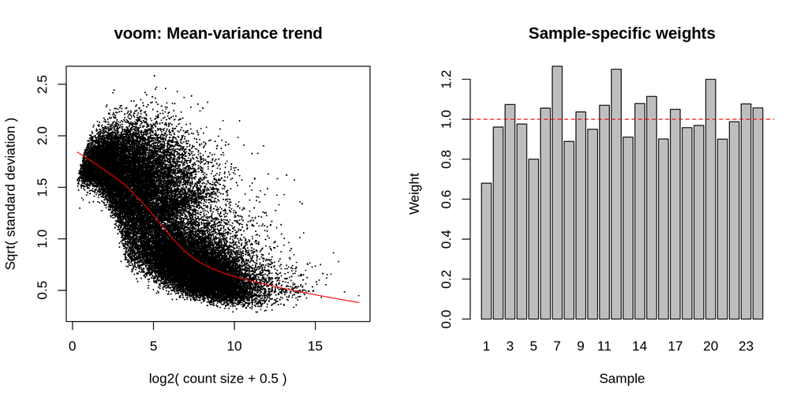

```r
## Transcript Features - Filtering approach 1 - Model option 1
tran_voom <- voomWithQualityWeights(dge_tran_a1_norm, design,plot = TRUE)
```

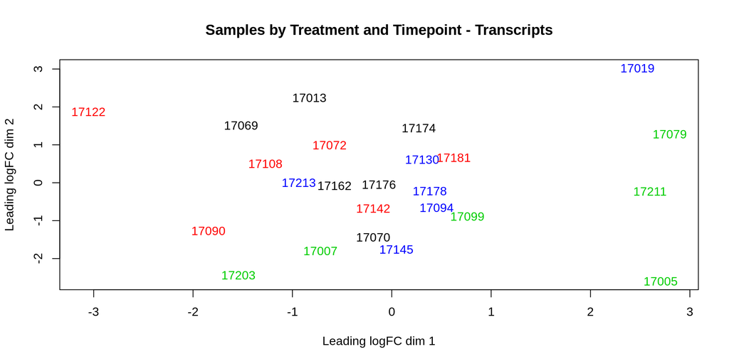

```r
# Simple MDS with samples colored by their treatment x time levels
plotMDS(tran_voom,col=as.numeric(interaction(meta$treatment,meta$timepoint)),main="Samples by Treatment and Timepoint - Transcripts")
```

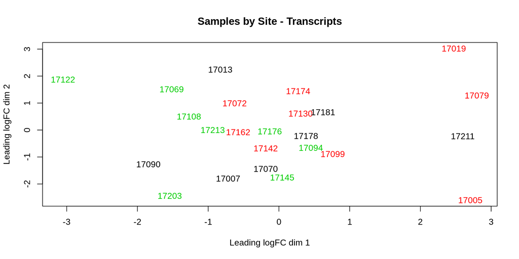

```r
# Simple MDS with samples colored by their site
plotMDS(tran_voom,col=as.numeric(meta$Pop),main="Samples by Site - Transcripts")
```

```r
# Saving the final transformation of the data (after individual weights)
# Going with Approach 2 and option 2 given this seems to make the most biological and experimental
# sense. (i.e. keep genes with expression in at least one treatment X time level and using
# specific contrasts for the specific hypotheses we with to test.
#saveRDS(dge_gene_a2_o2_voom,"/home/downeyam/Github/2017OAExp_Oysters/results/Transcriptomic/DGEListObj_withIndWeights_filterApproach2_plannedContrastMatrix.RData")
```

Looks like based on the mean-variance plots the relationship between sd or variance and expression looks reasonable for gene and transcript features and for either filtering approach.

### Check lib. size by treatment + time after individual weight correction

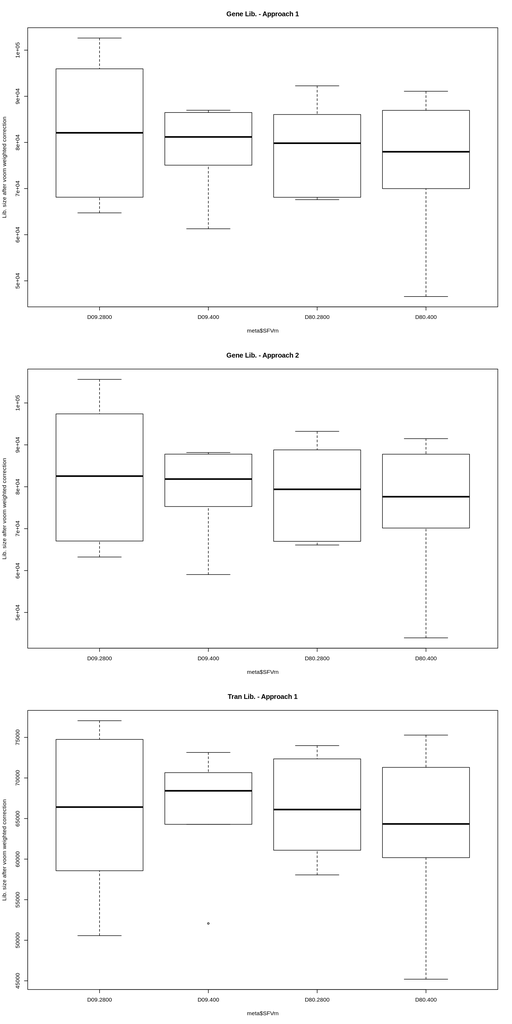

### Identify correlation between factors in design contrasts with blocking factor

- Use `duplicateCorrelation` from `limma` package
  - Estimate the correlation between technical replicates within the experiment. In this case tanks were replicate treatments (6 tanks per treatment). Each tank has two individuals (one from each timepoint). 12 tanks x 2 individuals = 24 samples.

**Note**: Same as `voom` transformation, the 4 gene feature objects are used and the 1 transcript feature.

```r
#Genes
gene_a1_o1_cor <- duplicateCorrelation(dge_gene_a1_o1_voom, design, block = meta$tankID)
gene_a1_o2_cor <- duplicateCorrelation(dge_gene_a1_o2_voom, design_alt, block = meta$tankID)
gene_a2_o1_cor <- duplicateCorrelation(dge_gene_a2_o1_voom, design, block = meta$tankID)
gene_a2_o2_cor <- duplicateCorrelation(dge_gene_a2_o2_voom, design_alt, block = meta$tankID)
# Transcript
tran_cor <- duplicateCorrelation(tran_voom, design, block = meta$tankID)

# Ran this model with and without this step. It doesn't seem to impact the outcome all that much.
```

### Run `lmFit` model and `Ebayes` from `limma`

**Fitting Model without contrasts**

```r
#Genes
lmf_gene_a1_o1 <- lmFit(dge_gene_a1_o1_voom, design,
                        block = meta$tankID,
                        correlation = gene_a1_o1_cor$consensus.correlation)
lmf_gene_a1_o2 <- lmFit(dge_gene_a1_o2_voom, design_alt,
                        block = meta$tankID,
                        correlation = gene_a1_o2_cor$consensus.correlation)
lmf_gene_a2_o1 <- lmFit(dge_gene_a2_o1_voom, design,
                        block = meta$tankID,
                        correlation = gene_a2_o1_cor$consensus.correlation)
lmf_gene_a2_o2 <- lmFit(dge_gene_a2_o2_voom, design_alt,
                        block = meta$tankID,
                        correlation = gene_a2_o2_cor$consensus.correlation)

#Transcripts
lmf_tran <- lmFit(tran_voom, design,
                        block = meta$tankID,
                        correlation = tran_cor$consensus.correlation)

#Run in eBayes first w/o contrasts
# Genes
bayes_gene_a1_o1_simple <- eBayes(lmf_gene_a1_o1,robust=TRUE)
bayes_gene_a1_o2_simple <- eBayes(lmf_gene_a1_o2,robust=TRUE)
bayes_gene_a2_o1_simple <- eBayes(lmf_gene_a2_o1,robust=TRUE)
bayes_gene_a2_o2_simple <- eBayes(lmf_gene_a2_o2,robust=TRUE)

# Transcript
bayes_tran_simple <- eBayes(lmf_tran,robust = TRUE)
```

**Refitting Option 1 with contrasts**

```r
# Genes - Filtering approach 1
lmf_gene_a1_o1_wContr <- contrasts.fit(lmf_gene_a1_o1,contr_mat)
# Genes -Filtering approach 2
lmf_gene_a2_o1_wContr <- contrasts.fit(lmf_gene_a1_o1,contr_mat)
#Transcripts
lmf_tran_wContr <- contrasts.fit(lmf_tran,contr_mat)

#Run in eBayes w contrasts
#Genes
bayes_gene_a1_o1_contr <- eBayes(lmf_gene_a1_o1_wContr,robust=TRUE)
bayes_gene_a2_o1_contr <- eBayes(lmf_gene_a2_o1_wContr,robust=TRUE)
#Transcript
bayes_tran_contr <- eBayes(lmf_tran_wContr,robust=TRUE)

#saveRDS(bayes_gene_a2_o1_contr,"/home/downeyam/Github/2017OAExp_Oysters/results/Transcriptomic/EBayesObj_gene_withIndWeights_filterApproach2_plannedContrastMatrix.RData")
#saveRDS(tran_fit2_contr,"/home/downeyam/Github/2017OAExp_Oysters/results/EBayesObj_transcript_withIndWeights_filterApproach2_plannedContrastMatrix.RData")
```

### Top Candidate Tables

**Gene Feature - Approach 1 - Option 1 (without contrasts)**

I run this chunk to show the default output from the single explanatory (4 level) model formula option, but really this model should only be examined within the context of the planned contrasts (next chunk).

```r
par(mfrow=c(1,1))
#topTable(bayes_gene_a1_o1_simple)
kable((toGene <- topTable(bayes_gene_a1_o1_simple)))%>%
    kable_styling() %>%
    scroll_box(width = "90%", height = "250px")
```

|  | GENEID | TXNAME | gene_id | chr | start | stop | predict | D09.2800 | D09.400 | D80.2800 | D80.400 | AveExpr | F | P.Value | adj.P.Val |
| --- | --- | --- | --- | --- | --- | --- | --- | --- | --- | --- | --- | --- | --- | --- | --- |
| LOC111120874 | LOC111120874 | rna7574_gene4454 | gene4454 | NC_035781.1 | 7828345 | 7847411 | serine/threonine-protein phosphatase 2B catalytic subunit alpha isoform-like, transcript variant X3 | 8.835113 | 8.867544 | 8.849549 | 8.879129 | 8.855201 | 36852.87 | 0 | 0 |
| LOC111125384 | LOC111125384 | rna20283_gene11740 | gene11740 | NC_035782.1 | 61276416 | 61305230 | protein PRRC2C-like | 9.944567 | 9.908728 | 9.908049 | 9.952593 | 9.925871 | 32932.87 | 0 | 0 |
| LOC111136938 | LOC111136938 | rna34696_gene20130 | gene20130 | NC_035784.1 | 50419298 | 50427916 | guanine nucleotide-binding protein subunit beta | 10.104367 | 10.005875 | 10.052657 | 10.142523 | 10.084005 | 32914.71 | 0 | 0 |
| LOC111127225 | LOC111127225 | rna5497_gene3231 | gene3231 | NC_035780.1 | 54830620 | 54833810 | elongation factor 1-alpha | 13.969196 | 13.858470 | 14.098249 | 13.843103 | 13.944062 | 32712.64 | 0 | 0 |
| LOC111129521 | LOC111129521 | rna27490_gene15941 | gene15941 | NC_035783.1 | 48328865 | 48331194 | mRNA decay activator protein ZFP36L1-like | 9.207870 | 9.301282 | 9.385877 | 9.397094 | 9.330850 | 28895.83 | 0 | 0 |
| LOC111136148 | LOC111136148 | rna29203_gene16961 | gene16961 | NC_035784.1 | 3917727 | 3953351 | helicase domino-like, transcript variant X1 | 9.393768 | 9.336022 | 9.297674 | 9.296608 | 9.328332 | 27956.18 | 0 | 0 |
| LOC111103220 | LOC111103220 | rna49168_gene28331 | gene28331 | NC_035786.1 | 53071821 | 53089582 | radixin-like, transcript variant X2 | 9.545191 | 9.466283 | 9.527363 | 9.633501 | 9.549927 | 27326.01 | 0 | 0 |
| LOC111127026 | LOC111127026 | rna19656_gene11339 | gene11339 | NC_035782.1 | 55300700 | 55320544 | bromodomain-containing protein 3-like | 8.576330 | 8.516194 | 8.590877 | 8.635654 | 8.582489 | 26458.19 | 0 | 0 |
| LOC111134425 | LOC111134425 | rna31697_gene18395 | gene18395 | NC_035784.1 | 25851119 | 25878027 | guanine nucleotide-binding protein G(o) subunit alpha, transcript variant X2 | 8.849144 | 8.848017 | 8.912162 | 8.931752 | 8.888840 | 26211.38 | 0 | 0 |
| LOC111101036 | LOC111101036 | rna42961_gene24792 | gene24792 | NC_035785.1 | 36230415 | 36255092 | protein hu-li tai shao-like, transcript variant X3 | 9.677156 | 9.508846 | 9.698544 | 9.397540 | 9.572608 | 26178.04 | 0 | 0 |

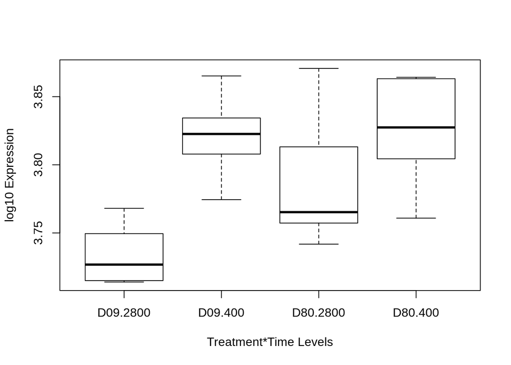

```r
# Boxplot for top target gene
boxplot(log10(unlist(geneC_all[rownames(geneC_all)==rownames(toGene)[1],]))~meta$SFVrn,
        ylab="log10 Expression",
        xlab="Treatment*Time Levels",
        main="")
```

**Gene Feature - Approach 1 - Option 1 (with contrasts)**

```r
par(mfrow=c(1,1))
#topTable(bayes_gene_a1_o1_contr)
kable((toGene <- topTable(bayes_gene_a1_o1_contr)))%>%
    kable_styling() %>%
    scroll_box(width = "90%", height = "250px")
```

|  | GENEID | TXNAME | gene_id | chr | start | stop | predict | CvE_D9 | CvE_D80 | C_D9vD80 | Diff | AveExpr | F | P.Value | adj.P.Val |
| --- | --- | --- | --- | --- | --- | --- | --- | --- | --- | --- | --- | --- | --- | --- | --- |
| LOC111122316 | LOC111122316 | rna7111_gene4208 | gene4208 | NC_035781.1 | 3367902 | 3396614 | ankyrin-2-like, transcript variant X30 | 0.1070859 | 0.2661329 | 0.4507389 | -0.1590469 | 10.183682 | 13.67262 | 0.0000262 | 0.2461174 |
| LOC111131726 | LOC111131726 | rna27129_gene15666 | gene15666 | NC_035783.1 | 42855533 | 42858371 | laccase domain-containing protein 1-like, transcript variant X1 | 0.1475553 | -0.7889177 | -0.9851209 | 0.9364730 | 4.159089 | 13.36997 | 0.0000307 | 0.2461174 |
| LOC111103954 | LOC111103954 | rna49116_gene28296 | gene28296 | NC_035786.1 | 52619970 | 52637617 | adhesion G-protein coupled receptor D1-like, transcript variant X2 | 0.4333424 | 0.3131519 | 0.7883716 | 0.1201905 | 7.709717 | 13.31749 | 0.0000320 | 0.2461174 |
| LOC111107118 | LOC111107118 | rna54587_gene31601 | gene31601 | NC_035787.1 | 51537191 | 51547974 | neurocalcin homolog, transcript variant X3 | 0.3228185 | 0.0798791 | 0.7988280 | 0.2429394 | 5.408053 | 12.59167 | 0.0000473 | 0.2461174 |
| LOC111128104 | LOC111128104 | rna22511_gene13063 | gene13063 | NC_035783.1 | 4373861 | 4376851 | uncharacterized LOC111128104 | -0.4702739 | -0.1703091 | -0.9496858 | -0.2999648 | 4.502643 | 12.42815 | 0.0000518 | 0.2461174 |
| LOC111120835 | LOC111120835 | rna8172_gene4759 | gene4759 | NC_035781.1 | 12113095 | 12126957 | transmembrane 9 superfamily member 4-like | -0.3199965 | -0.2064099 | -0.5275339 | -0.1135867 | 5.880637 | 11.55845 | 0.0000838 | 0.2502576 |
| LOC111134788 | LOC111134788 | rna38717_gene22287 | gene22287 | NC_035784.1 | 85555274 | 85574606 | neurogenic locus notch homolog protein 1-like | -0.6194677 | 0.1303682 | -0.2770008 | -0.7498359 | 7.152997 | 11.52785 | 0.0000863 | 0.2502576 |
| LOC111111878 | LOC111111878 | rna63568_gene37058 | gene37058 | NC_035788.1 | 86181381 | 86187447 | alpha-amylase-like | -2.8610471 | 1.0397916 | -0.0380822 | -3.9008387 | 5.286239 | 11.16586 | 0.0001066 | 0.2502576 |
| LOC111121784 | LOC111121784 | rna7775_gene4559 | gene4559 | NC_035781.1 | 9251278 | 9252371 | uncharacterized LOC111121784 | -0.9263431 | -0.1705984 | -1.0517893 | -0.7557447 | 2.163460 | 10.88374 | 0.0001252 | 0.2502576 |
| LOC111135911 | LOC111135911 | rna36681_gene21167 | gene21167 | NC_035784.1 | 66325187 | 66372020 | myoferlin-like, transcript variant X16 | 0.1635114 | 0.2522714 | 0.4268114 | -0.0887600 | 10.152838 | 10.85209 | 0.0001271 | 0.2502576 |

```r
# Boxplot for top target gene
boxplot(log10(unlist(geneC_all[rownames(geneC_all)==rownames(toGene)[1],]))~meta$SFVrn,
        ylab="log10 Expression",
        xlab="Treatment*Time Levels",
        main="")
```

[output not shown]

```r
#Summary Table
kable(summary(decideTests(bayes_gene_a1_o1_contr,adjust.method = "fdr",p.value=0.05)))%>%
  kable_styling()
```

|  | CvE_D9 | CvE_D80 | C_D9vD80 | Diff |
| --- | --- | --- | --- | --- |
| Down | 0 | 0 | 0 | 0 |
| NotSig | 23743 | 23743 | 23743 | 23743 |
| Up | 0 | 0 | 0 | 0 |

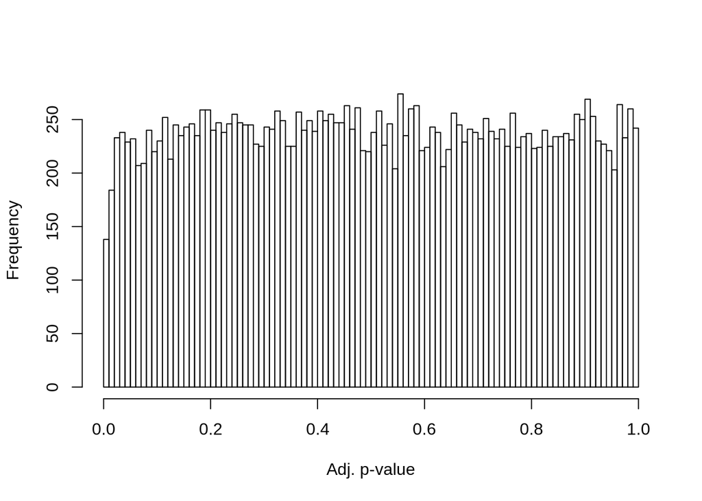

```r
# Adjusted p-value histogram
hist(bayes_gene_a1_o1_contr$p.value[,2],xlim=c(0,1),breaks=100,main="",xlab="Adj. p-value")
```

**Gene Feature - Approach 1 - Option 2**

```r
par(mfrow=c(1,1))
#topTable(bayes_gene_a1_o2_simple)
kable((toGene <- topTable(bayes_gene_a1_o2_simple)))%>%
    kable_styling() %>%
    scroll_box(width = "90%", height = "250px")
```

```
## Removing intercept from test coefficients
```

|  | GENEID | TXNAME | gene_id | chr | start | stop | predict | Treatment2800 | Time80 | Treatment2800.Time80 | AveExpr | F | P.Value | adj.P.Val |
| --- | --- | --- | --- | --- | --- | --- | --- | --- | --- | --- | --- | --- | --- | --- |
| LOC111122316 | LOC111122316 | rna7111_gene4208 | gene4208 | NC_035781.1 | 3367902 | 3396614 | ankyrin-2-like, transcript variant X30 | 0.1070859 | -0.4507389 | 0.1590469 | 10.183682 | 13.71072 | 2.57e-05 | 0.2180264 |
| LOC111103954 | LOC111103954 | rna49116_gene28296 | gene28296 | NC_035786.1 | 52619970 | 52637617 | adhesion G-protein coupled receptor D1-like, transcript variant X2 | 0.4333424 | -0.7883716 | -0.1201905 | 7.709717 | 13.28356 | 3.26e-05 | 0.2180264 |
| LOC111131726 | LOC111131726 | rna27129_gene15666 | gene15666 | NC_035783.1 | 42855533 | 42858371 | laccase domain-containing protein 1-like, transcript variant X1 | 0.1475553 | 0.9851209 | -0.9364730 | 4.159089 | 13.20097 | 3.36e-05 | 0.2180264 |
| LOC111128104 | LOC111128104 | rna22511_gene13063 | gene13063 | NC_035783.1 | 4373861 | 4376851 | uncharacterized LOC111128104 | -0.4702739 | 0.9496858 | 0.2999648 | 4.502643 | 12.59913 | 4.72e-05 | 0.2180264 |
| LOC111107118 | LOC111107118 | rna54587_gene31601 | gene31601 | NC_035787.1 | 51537191 | 51547974 | neurocalcin homolog, transcript variant X3 | 0.3228185 | -0.7988280 | -0.2429394 | 5.408053 | 12.45719 | 5.10e-05 | 0.2180264 |
| LOC111120835 | LOC111120835 | rna8172_gene4759 | gene4759 | NC_035781.1 | 12113095 | 12126957 | transmembrane 9 superfamily member 4-like | -0.3199965 | 0.5275339 | 0.1135867 | 5.880637 | 11.57843 | 8.29e-05 | 0.2180264 |
| LOC111134788 | LOC111134788 | rna38717_gene22287 | gene22287 | NC_035784.1 | 85555274 | 85574606 | neurogenic locus notch homolog protein 1-like | -0.6194677 | 0.2770008 | 0.7498359 | 7.152997 | 11.56832 | 8.43e-05 | 0.2180264 |
| LOC111111878 | LOC111111878 | rna63568_gene37058 | gene37058 | NC_035788.1 | 86181381 | 86187447 | alpha-amylase-like | -2.8610471 | 0.0380822 | 3.9008387 | 5.286239 | 11.46370 | 8.95e-05 | 0.2180264 |
| LOC111121784 | LOC111121784 | rna7775_gene4559 | gene4559 | NC_035781.1 | 9251278 | 9252371 | uncharacterized LOC111121784 | -0.9263431 | 1.0517893 | 0.7557447 | 2.163460 | 11.28526 | 9.87e-05 | 0.2180264 |
| LOC111137004 | LOC111137004 | rna1480_gene843 | gene843 | NC_035780.1 | 13801448 | 13829339 | bridging integrator 2-like | -3.4959233 | -0.0957398 | 3.4891348 | 5.473338 | 11.00833 | 1.17e-04 | 0.2180264 |

```r
# Boxplot for top target gene
boxplot(log10(unlist(geneC_all[rownames(geneC_all)==rownames(toGene)[1],]))~meta$SFVrn,
        ylab="log10 Expression",
        xlab="Treatment*Time Levels",
        main="")
```

[output not shown]

```r
#Summary Table
kable(summary(decideTests(bayes_gene_a1_o2_simple,adjust.method = "fdr",p.value=0.05))) %>%
  kable_styling()
```

|  | (Intercept) | Treatment2800 | Time80 | Treatment2800:Time80 |
| --- | --- | --- | --- | --- |
| Down | 222 | 0 | 0 | 0 |
| NotSig | 5728 | 23743 | 23743 | 23743 |
| Up | 17793 | 0 | 0 | 0 |

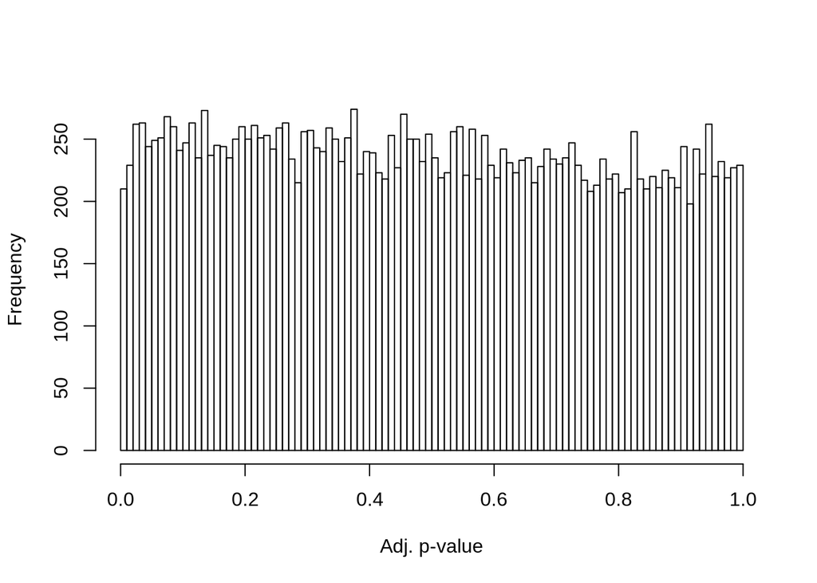

```r
# Adjusted p-value histogram
hist(bayes_gene_a1_o2_simple$p.value[,2],xlim=c(0,1),breaks=100,main="",xlab="Adj. p-value")
```

**Gene Feature - Approach 2 - Option 1 (without contrasts)**

I don’t run this chunk because as explained above the actual default contrasts don’t have much meaning even if significant. We really only care about utilizing this formula in the context of our planned contrasts.

```r
par(mfrow=c(1,1))
#topTable(bayes_gene_a2_o1_simple)
kable((toGene <- topTable(bayes_gene_a2_o1_simple)))%>%
    kable_styling() %>%
    scroll_box(width = "90%", height = "250px")
# Boxplot for top target gene
boxplot(log10(unlist(geneC_all[rownames(geneC_all)==rownames(toGene)[1],]))~meta$SFVrn,
        ylab="log10 Expression",
        xlab="Treatment*Time Levels",
        main="")
# Adjusted p-value histogram
hist(bayes_gene_a2_o1_simple$p.value[,2],xlim=c(0,1),breaks=100,main="",xlab="Adj. p-value")
```

**Gene Feature - Approach 2 - Option 1 (with contrasts)**

```r
par(mfrow=c(1,1))
#topTable(bayes_gene_a2_o1_contr)
kable((toGene <- topTable(bayes_gene_a2_o1_contr)))%>%
    kable_styling() %>%
    scroll_box(width = "90%", height = "250px")
```

|  | GENEID | TXNAME | gene_id | chr | start | stop | predict | CvE_D9 | CvE_D80 | C_D9vD80 | Diff | AveExpr | F | P.Value | adj.P.Val |
| --- | --- | --- | --- | --- | --- | --- | --- | --- | --- | --- | --- | --- | --- | --- | --- |
| LOC111122316 | LOC111122316 | rna7111_gene4208 | gene4208 | NC_035781.1 | 3367902 | 3396614 | ankyrin-2-like, transcript variant X30 | 0.1070859 | 0.2661329 | 0.4507389 | -0.1590469 | 10.183682 | 13.67262 | 0.0000262 | 0.2461174 |
| LOC111131726 | LOC111131726 | rna27129_gene15666 | gene15666 | NC_035783.1 | 42855533 | 42858371 | laccase domain-containing protein 1-like, transcript variant X1 | 0.1475553 | -0.7889177 | -0.9851209 | 0.9364730 | 4.159089 | 13.36997 | 0.0000307 | 0.2461174 |
| LOC111103954 | LOC111103954 | rna49116_gene28296 | gene28296 | NC_035786.1 | 52619970 | 52637617 | adhesion G-protein coupled receptor D1-like, transcript variant X2 | 0.4333424 | 0.3131519 | 0.7883716 | 0.1201905 | 7.709717 | 13.31749 | 0.0000320 | 0.2461174 |
| LOC111107118 | LOC111107118 | rna54587_gene31601 | gene31601 | NC_035787.1 | 51537191 | 51547974 | neurocalcin homolog, transcript variant X3 | 0.3228185 | 0.0798791 | 0.7988280 | 0.2429394 | 5.408053 | 12.59167 | 0.0000473 | 0.2461174 |
| LOC111128104 | LOC111128104 | rna22511_gene13063 | gene13063 | NC_035783.1 | 4373861 | 4376851 | uncharacterized LOC111128104 | -0.4702739 | -0.1703091 | -0.9496858 | -0.2999648 | 4.502643 | 12.42815 | 0.0000518 | 0.2461174 |
| LOC111120835 | LOC111120835 | rna8172_gene4759 | gene4759 | NC_035781.1 | 12113095 | 12126957 | transmembrane 9 superfamily member 4-like | -0.3199965 | -0.2064099 | -0.5275339 | -0.1135867 | 5.880637 | 11.55845 | 0.0000838 | 0.2502576 |
| LOC111134788 | LOC111134788 | rna38717_gene22287 | gene22287 | NC_035784.1 | 85555274 | 85574606 | neurogenic locus notch homolog protein 1-like | -0.6194677 | 0.1303682 | -0.2770008 | -0.7498359 | 7.152997 | 11.52785 | 0.0000863 | 0.2502576 |
| LOC111111878 | LOC111111878 | rna63568_gene37058 | gene37058 | NC_035788.1 | 86181381 | 86187447 | alpha-amylase-like | -2.8610471 | 1.0397916 | -0.0380822 | -3.9008387 | 5.286239 | 11.16586 | 0.0001066 | 0.2502576 |
| LOC111121784 | LOC111121784 | rna7775_gene4559 | gene4559 | NC_035781.1 | 9251278 | 9252371 | uncharacterized LOC111121784 | -0.9263431 | -0.1705984 | -1.0517893 | -0.7557447 | 2.163460 | 10.88374 | 0.0001252 | 0.2502576 |
| LOC111135911 | LOC111135911 | rna36681_gene21167 | gene21167 | NC_035784.1 | 66325187 | 66372020 | myoferlin-like, transcript variant X16 | 0.1635114 | 0.2522714 | 0.4268114 | -0.0887600 | 10.152838 | 10.85209 | 0.0001271 | 0.2502576 |

```r
# Boxplot for top target gene
boxplot(log10(unlist(geneC_all[rownames(geneC_all)==rownames(toGene)[1],]))~meta$SFVrn,
        ylab="log10 Expression",
        xlab="Treatment*Time Levels",
        main="")
```

[output not shown]

```r
#Summary Table
kable(summary(decideTests(bayes_gene_a2_o1_contr,adjust.method = "fdr",p.value=0.05))) %>%
  kable_styling()
```

|  | CvE_D9 | CvE_D80 | C_D9vD80 | Diff |
| --- | --- | --- | --- | --- |
| Down | 0 | 0 | 0 | 0 |
| NotSig | 23743 | 23743 | 23743 | 23743 |
| Up | 0 | 0 | 0 | 0 |

```r
#Alternative p-value value correction approach approach
bayes_gene_a2_o1_contr_qval <- fdrtool(bayes_gene_a2_o1_contr$t[,1],statistic = "normal",verbose = FALSE,plot=FALSE)
bayes_gene_a2_o1_contr_qval$qval[bayes_gene_a2_o1_contr_qval$qval < 0.05]
```

```
## named numeric(0)
```

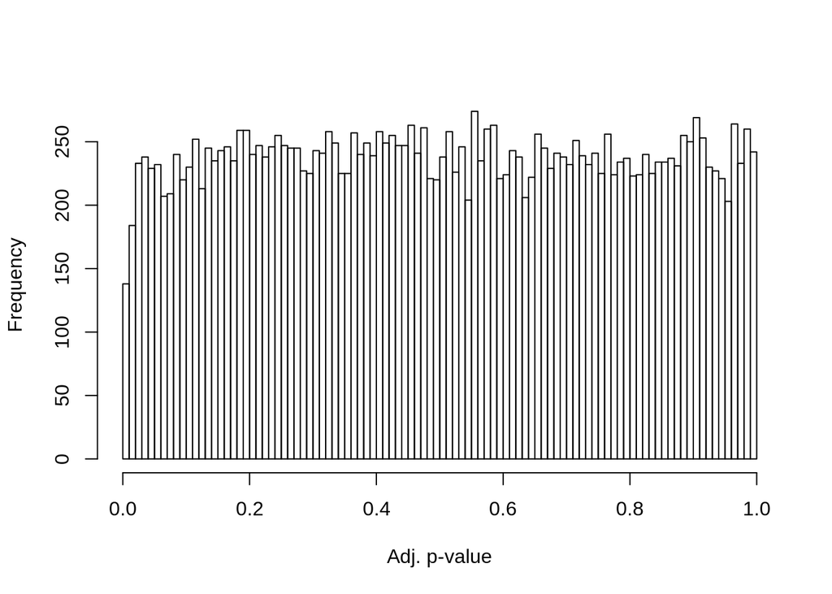

```r
# Adjusted p-value histogram
hist(bayes_gene_a2_o1_contr$p.value[,2],xlim=c(0,1),breaks=100,main="",xlab="Adj. p-value")
```

**Transcript Feature - Approach 1 - Option 1 (with contrasts)**

```r
par(mfrow=c(1,1))
#topTable(bayes_tran_contr,adjust="fdr",p.value=0.2, number=Inf ,resort.by="P")

kable((toTran <- topTable(bayes_tran_contr,adjust="fdr",p.value=0.05, number=Inf ,resort.by="P")))%>%
    kable_styling() %>%
    scroll_box(width = "90%", height = "250px")
```

|  | GENEID | TXNAME | gene_id | chr | start | stop | predict | CvE_D9 | CvE_D80 | C_D9vD80 | Diff | AveExpr | F | P.Value | adj.P.Val |
| --- | --- | --- | --- | --- | --- | --- | --- | --- | --- | --- | --- | --- | --- | --- | --- |
| rna20092_gene11596 | LOC111122815 | rna20092_gene11596 | gene11596 | NC_035782.1 | 59034637 | 59059046 | flotillin-1-like, transcript variant X6 | -0.3279761 | 0.1378941 | -0.6173570 | -0.4658702 | 6.583518 | 20.97160 | 1.0e-06 | 0.0361359 |
| rna63330_gene36906 | LOC111111359 | rna63330_gene36906 | gene36906 | NC_035788.1 | 82924988 | 82934620 | reticulophagy regulator 3-like, transcript variant X2 | -5.1551651 | -0.4235105 | -0.1216301 | -4.7316546 | 3.465625 | 19.11549 | 2.2e-06 | 0.0389018 |

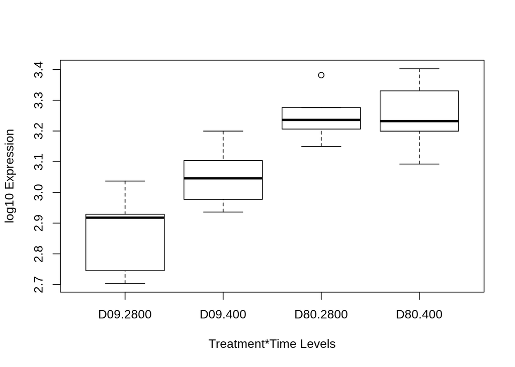

```r
# Boxplot for top target gene
boxplot(log10(unlist(tranC_all[rownames(tranC_all)==rownames(toTran)[1],]))~meta$SFVrn,
        ylab="log10 Expression",
        xlab="Treatment*Time Levels",
        main="")
```

```r
#Summary Table
kable(summary(decideTests(bayes_tran_contr,adjust.method = "fdr",p.value=0.05))) %>%
  kable_styling()
```

|  | CvE_D9 | CvE_D80 | C_D9vD80 | Diff |
| --- | --- | --- | --- | --- |
| Down | 0 | 0 | 0 | 0 |
| NotSig | 35796 | 35796 | 35796 | 35796 |
| Up | 0 | 0 | 0 | 0 |

```r
# Checking if p-value correction gives similar results using alternative approach (fdrtools)
out.min <- fdrtool(bayes_tran_contr$t[,1],verbose = FALSE,plot=FALSE)
out.min$qval[out.min$qval < 0.05]
```

```
## rna19676_gene11349 rna48834_gene28124 rna58229_gene33858
##        0.002263594        0.009674905        0.023150454
## rna63330_gene36906
##        0.003803256
```

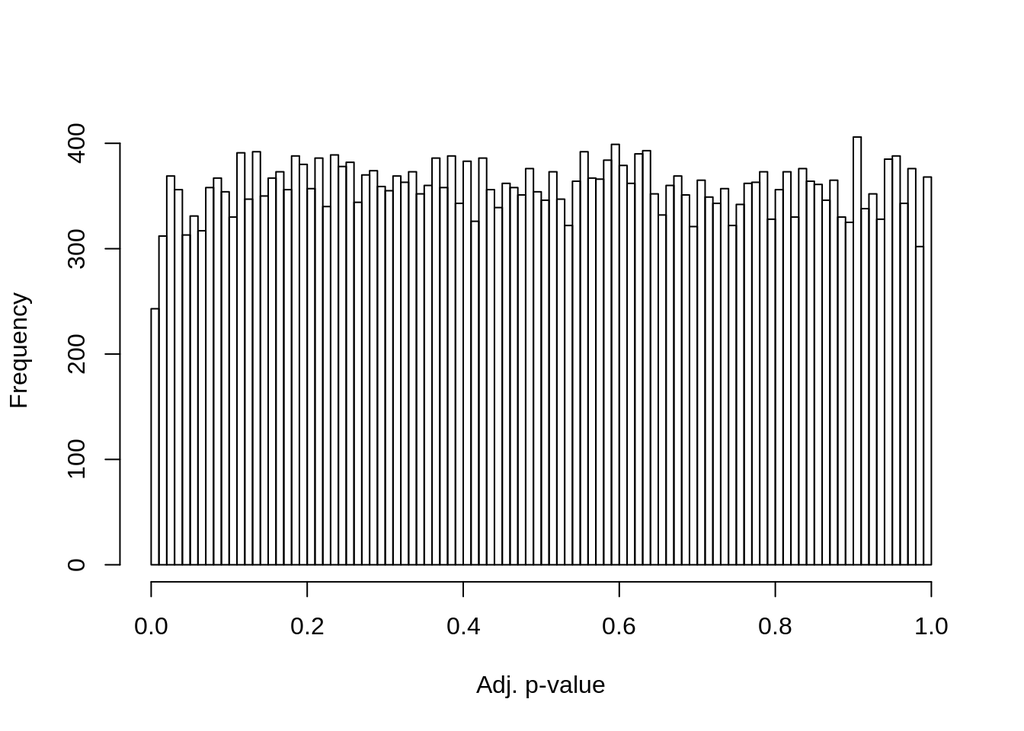

```r
# Adjusted p-value histogram
hist(bayes_tran_contr$p.value[,2],xlim=c(0,1),breaks=100,main="",xlab="Adj. p-value")
```

## Data Visualization

### Volcano Plots - Gene Feature - Approach 2 - Option 1 with contrasts

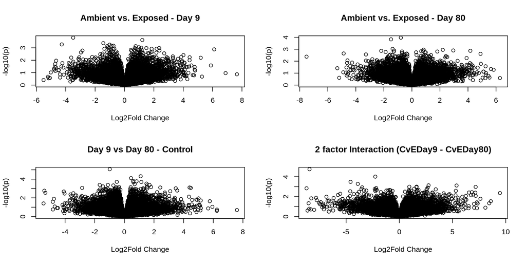

### Volcano Plots - Option Comparison

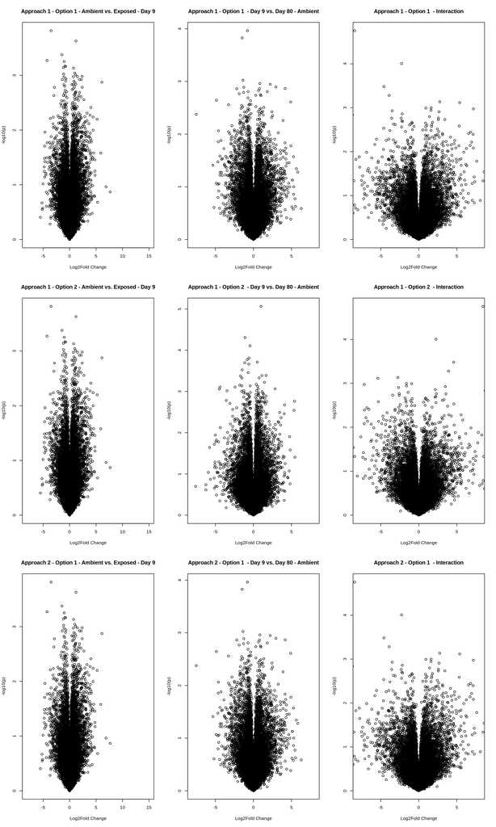

### Volcano Plots - Transcript Feature - Approach 1 - Option 1 with contrasts

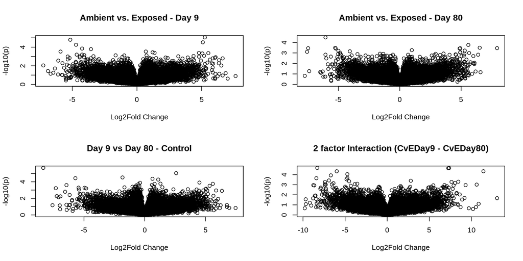

### Conclusions

From these findings I decided to run with the second filtering option (i.e. `approach 2`), which only retained genes or transcripts that were present in at least one treatment-time level in at least 5 samples. This seems like the most sensible filtering criteria to ensure that one genes that display consistent expression in at least one treatment-time level are kept. In addition, we confirmed that the custom contrast matrix and planned comparisons are performing the way they should be, so I will be focusing on the potentially differentially expressed genes (and transcripts) from those contrasts.